# Exam1

Maria

2023-03-07

### Ex. 4

The ‘ggplot’ works in layers. A layer is a combination of data, stat and/or geom. Layering is the process of adding multiple layers (graphical elements) to a graph. You can add layers using the ‘+’ operator in ggplot and it is placed at the end of each line of the code containing a layer. For example, we can add points ‘geom_point()’ and lines ‘geom_smooth()’ to a plot by adding them (‘+’) as separate layers. Scales control the mapping between data and aesthetics, for instance the size, type, or color of points in a plot. We can customize the scales using the ‘scale_ function’ in ggplot. For example, the ‘scale_color_gradient()’ function changes the color scale. Themes customize the overall appearance of the plot, such as titles, background color, gridlines, legends, etc. You can customize the theme using the ‘theme_ function’ in ggplot. For example, ‘theme_grey()’ results in theme with a grey background and ‘theme_bw()’ a theme with a white background. A facet breaks a plot into panels. Faceting is the process of dividing the data into subsets, based on the values of a categorical variable, then generates separated plots for each subset. You can create facets using the ‘facet_ wrap(~variablename)’ in ggplot.

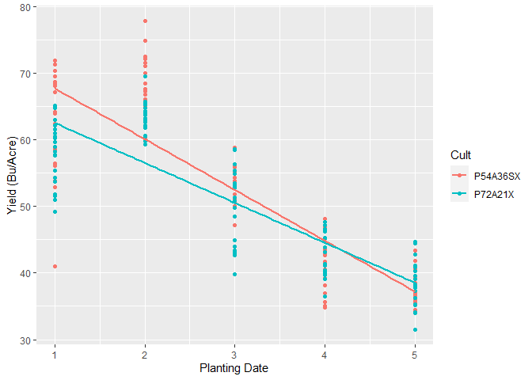

```r
library (ggplot2)
plantpop <- read.csv("PlantPop.csv")

##Layering##

ggplot(plantpop, aes (x=Date, y=Yield, color=Cult)) +
  geom_point() +
  geom_smooth (method = lm, se = FALSE) +
  ylab ("Yield (Bu/Acre)") +
  xlab ("Planting Date")
```

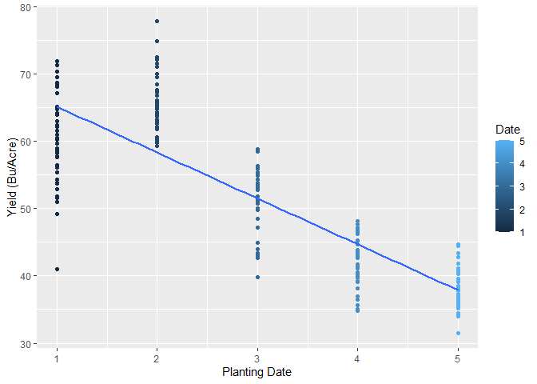

```r
##Scales##

ggplot(plantpop, aes (x=Date, y=Yield)) +
  geom_point(aes(color=Date)) +
  geom_smooth (method = lm, se = FALSE) +
  ylab ("Yield (Bu/Acre)") +
  xlab ("Planting Date")
```

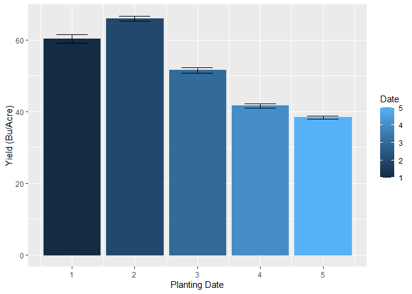

```r
ggplot (plantpop, aes (x=Date, y=Yield)) +
  stat_summary(fun=mean, geom="bar", position = "dodge", aes(color=Date, fill=Date)) +
  stat_summary(fun.data = mean_se, geom = "errorbar", position = position_dodge(width=0.9), width = 0.5) +
  ylab ("Yield (Bu/Acre)") +
  xlab ("Planting Date")
```

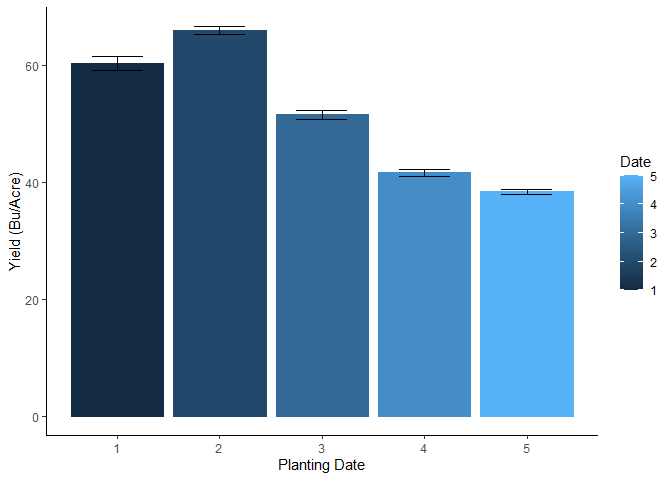

```r
##Themes##

ggplot (plantpop, aes (x=Date, y=Yield)) +
  stat_summary(fun=mean, geom="bar", position = "dodge", aes(color=Date, fill=Date)) +
  stat_summary(fun.data = mean_se, geom = "errorbar", position = "dodge", width = 0.5) +
  ylab ("Yield (Bu/Acre)") +
  xlab ("Planting Date") +
  theme_classic()
```

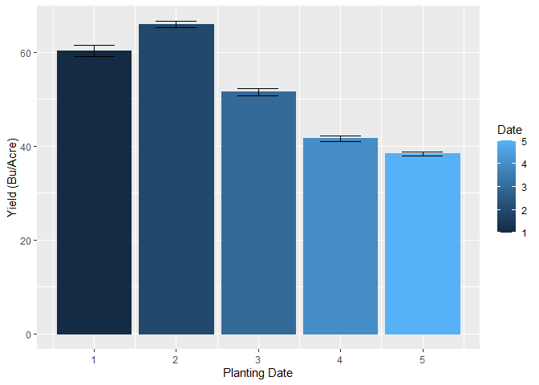

```r
ggplot (plantpop, aes (x=Date, y=Yield)) +
  stat_summary(fun=mean, geom="bar", position = "dodge", aes(color=Date, fill=Date)) +
  stat_summary(fun.data = mean_se, geom = "errorbar", position = "dodge", width = 0.5) +
  ylab ("Yield (Bu/Acre)") +
  xlab ("Planting Date") +
  theme_gray()
```

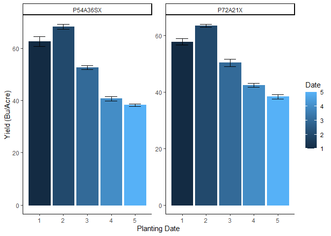

```r
##Facets##

ggplot (plantpop, aes (x=Date, y=Yield)) +
  stat_summary(fun=mean, geom="bar", position = "dodge", aes(color=Date, fill=Date)) +
  stat_summary(fun.data = mean_se, geom = "errorbar", position = "dodge", width = 0.5) +
  ylab ("Yield (Bu/Acre)") +
  xlab ("Planting Date") +
  theme_classic() +
  facet_wrap(~Cult, scale = "free")
```

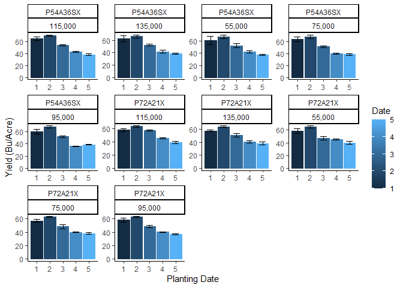

```r
ggplot (plantpop, aes (x=Date, y=Yield)) +
  stat_summary(fun=mean, geom="bar", position = "dodge", aes(color=Date, fill=Date)) +
  stat_summary(fun.data = mean_se, geom = "errorbar", position = "dodge", width = 0.5) +
  ylab ("Yield (Bu/Acre)") +
  xlab ("Planting Date") +
  theme_classic() +
  facet_wrap(~Cult*Density, scale = "free")
```

### Ex. 5

5. Vector, matrix, and dataframe are all data structure that can be used in R. The vector is the most basic R data objects. It is a one-dimensional display of elements of the same data type (numeric, character, or logical). It can be thought of a list of elements saved together as an object. Vectors are used to create dataframes and matrixes. A matrix, differently from the vector, is a two-dimensional array of elements. It is an atomic object that can contain only one type of data class (numeric, character, or logical). It is created using a vector input and it has fixed number of columns and rows. It can be thought of as a table of elements. A matrix can be treated as a vector if we have a single column or row. A dataframe is very similar to a matrix, it is also a two-dimensional array of elements, but differently it can contain multiple data types together. A dataframe is a list of vectors with equal length where each columns can be a different data types. It can be thought of as a spreadsheet.

```r
subset1 <- ToothGrowth[ToothGrowth$supp == "VC", ]
subset1
```

```
##     len supp dose
## 1   4.2   VC  0.5
## 2  11.5   VC  0.5
## 3   7.3   VC  0.5
## 4   5.8   VC  0.5
## 5   6.4   VC  0.5
## 6  10.0   VC  0.5
## 7  11.2   VC  0.5
## 8  11.2   VC  0.5
## 9   5.2   VC  0.5
## 10  7.0   VC  0.5
## 11 16.5   VC  1.0
## 12 16.5   VC  1.0
## 13 15.2   VC  1.0
## 14 17.3   VC  1.0
```

[output cut: 16 more lines]

```r
subset1 <- subset(ToothGrowth, (supp == "VC"))
subset1
```

```
##     len supp dose
## 1   4.2   VC  0.5
## 2  11.5   VC  0.5
## 3   7.3   VC  0.5
## 4   5.8   VC  0.5
## 5   6.4   VC  0.5
## 6  10.0   VC  0.5
## 7  11.2   VC  0.5
## 8  11.2   VC  0.5
## 9   5.2   VC  0.5
## 10  7.0   VC  0.5
## 11 16.5   VC  1.0
## 12 16.5   VC  1.0
## 13 15.2   VC  1.0
## 14 17.3   VC  1.0
```

[output cut: 16 more lines]

```r
subset2 <- ToothGrowth[ToothGrowth$supp == "VC" & ToothGrowth$dose == 0.5, ]
subset2
```

```
##     len supp dose
## 1   4.2   VC  0.5
## 2  11.5   VC  0.5
## 3   7.3   VC  0.5
## 4   5.8   VC  0.5
## 5   6.4   VC  0.5
## 6  10.0   VC  0.5
## 7  11.2   VC  0.5
## 8  11.2   VC  0.5
## 9   5.2   VC  0.5
## 10  7.0   VC  0.5
```

```r
subset2 <- subset(ToothGrowth, (supp == "VC" & dose == 0.5))
subset2
```

```
##     len supp dose
## 1   4.2   VC  0.5
## 2  11.5   VC  0.5
## 3   7.3   VC  0.5
## 4   5.8   VC  0.5
## 5   6.4   VC  0.5
## 6  10.0   VC  0.5
## 7  11.2   VC  0.5
## 8  11.2   VC  0.5
## 9   5.2   VC  0.5
## 10  7.0   VC  0.5
```

```r
subset3 <- ToothGrowth[ToothGrowth$supp == "VC" & ToothGrowth$dose == 0.5, c("len")]
subset3
```

```
##  [1]  4.2 11.5  7.3  5.8  6.4 10.0 11.2 11.2  5.2  7.0
```

```r
subset3 <- subset(ToothGrowth, supp == "VC" & dose == 0.5, select = "len")
subset3
```

```
##     len
## 1   4.2
## 2  11.5
## 3   7.3
## 4   5.8
## 5   6.4
## 6  10.0
## 7  11.2
## 8  11.2
## 9   5.2
## 10  7.0
```